# Homography Estimation

### Contents

1. Estimating Homography with Linear Least-Squares Minimization
2. Linear Least-Squares Minimization with Inhomogenous Equations
3. Robust Homography Estimation with RANSAC Algorithm

### Estimating Homography with Linear Least-Squares Minimization

This BlogPost describes about the 2D to 2D homography correspondences. But most of the concepts presented here require knowledge of [Projective Geometry in 2 Dimensions](https://prithviramg.github.io/posts/Projective%20Geometry%20and%20Transformations%20of%202D.html)

We want to estimate the $3\times 3$ homography $H$ that relates point in two different planes through $x' = Hx$. We are given a set of correspondences $(x,x')$ that may include sampling and other measurement errors. Some of these correspondences may also be just plain wrong. We now express $H = \begin{pmatrix} h_{11}&h_{12}&h_{13} \\ h_{21}&h_{22}&h_{23} \\ h_{31}&h_{32}&h_{33} \end{pmatrix}$ as $H = \begin{pmatrix} {h^1}^T \\ {h^2}^T \\ {h^3}^T \end{pmatrix}$, where $h^1 = \begin{pmatrix} h_{11}\\h_{12}\\h_{13}\\\end{pmatrix}$, $h^2 = \begin{pmatrix} h_{21}\\h_{22}\\h_{23}\\\end{pmatrix}$ and $h^3 = \begin{pmatrix} h_{31}\\h_{32}\\h_{33}\\\end{pmatrix}$. With this new way of writing the $H$ matrix, we have $Hx = \begin{pmatrix} {h^1}^T{x_{3 \times 1}} \\ {h^2}^T{x_{3 \times 1}} \\ {h^3}^T{x_{3 \times 1}} \end{pmatrix}$

Under the assumption that our correspondences are error-free (this assumption will be relaxed later), it must be the case that for a given correspondence $(x,x')$, the vectors $x'$ and $Hx$ are identical. It must be therefore follow that $x' \times Hx = 0$, writing $x' = \begin{pmatrix}x'\\ y'\\ w'\end{pmatrix}$, we can therefore say $\begin{pmatrix} x'\\y'\\w'\end{pmatrix} \times \begin{pmatrix} {h^1}^T{x_{3 \times 1}} \\ {h^2}^T{x_{3 \times 1}} \\ {h^3}^T{x_{3 \times 1}} \end{pmatrix} = \begin{pmatrix} 0\\0\\0 \end{pmatrix}$

The vector cross product shown above yields: $\begin{pmatrix} {\overrightarrow 0}^Th^1 - w'{x_{3 \times 1}}^Th^2 + y'{x_{3 \times 1}}^Th^3 \\ w'{x_{3 \times 1}}^Th^1 + {\overrightarrow 0}^Th^2 - x'{x_{3 \times 1}}^Th^3 \\ -y'{x_{3 \times 1}}^Th^1 + x'{x_{3 \times 1}}^Th^2 + {\overrightarrow 0}^T{x_{3 \times 1}}^Th^3\end{pmatrix} = \begin{pmatrix} 0\\0\\0 \end{pmatrix}$. These 3 equations are not linearly independent, if we add $x'$ times the first equation with $y'$ times the second equation, you get $w'$ times the third equation. Therefore, retaining only the first two equation : $\begin{pmatrix} {\overrightarrow 0}^T & -w'{x_{3 \times 1}}^T & y'{x_{3 \times 1}}^T \\ w'{x_{3 \times 1}}^T & {\overrightarrow 0}^T & -x'{x_{3 \times 1}}^T\end{pmatrix}_{2 \times 9}\begin{pmatrix} h^1\\h^2\\h^3 \end{pmatrix}_{9 \times 1} = {\overrightarrow 0}_{2 \times 1}$. Each $(x,x')$ correspondence gives us a pair of equations expressed by the form $A\overrightarrow h = \overrightarrow 0$, where $A$ is the $2\times 9$ matrix shown in the previous bullet and $\overrightarrow h = \begin{pmatrix} h_{11}\\h_{12}\\h_{13}\\h_{21}\\h_{22}\\h_{23}\\h_{31}\\h_{32}\\h_{33}\end{pmatrix}$

Now consider, we are given $N$ correspondences $(x_i,{x'_i})$ for $i = 1,2,\dots,N$, we write $A_i\overrightarrow h = \overrightarrow 0$ for the two equations of the $i^{th}$ correspondence, we can now stack all the resutlting $2N$ equations in $A\overrightarrow h = \overrightarrow 0$ with $$\begin{pmatrix} A_1\\A_2\\A_3\\\vdots\\A_N\end{pmatrix}_{2N \times 9}\begin{pmatrix} h_{11}\\h_{12}\\h_{13}\\h_{21}\\h_{22}\\h_{23}\\h_{31}\\h_{32}\\h_{33}\end{pmatrix}_{9 \times 1} = \begin{pmatrix} {\overrightarrow 0}^T & -w'_1{x_{1(3 \times 1)}}^T & y_1'{x_{1(3 \times 1)}}^T \\ w'_1{x_{1(3 \times 1)}}^T & {\overrightarrow 0}^T & -x'_1{x_{1(3 \times 1)}}^T \\ {\overrightarrow 0}^T & -w'_2{x_{2(3 \times 1)}}^T & y_2'{x_{2(3 \times 1)}}^T \\ w'_2{x_{2(3 \times 1)}}^T & {\overrightarrow 0}^T & -x'_2{x_{2(3 \times 1)}}^T \\ \vdots&\ddots&\vdots \\ {\overrightarrow 0}^T & -w'_n{x_{n(3 \times 1)}}^T & y_n'{x_{n(3 \times 1)}}^T \\ w'_n{x_{n(3 \times 1)}}^T & {\overrightarrow 0}^T & -x'_n{x_{n(3 \times 1)}}^T\end{pmatrix}_{2N \times 9}\begin{pmatrix} h_{11}\\h_{12}\\h_{13}\\h_{21}\\h_{22}\\h_{23}\\h_{31}\\h_{32}\\h_{33}\end{pmatrix}_{9 \times 1} = 0_{2N \times 1}$$

More Generally, lets say we have a system of homogenous equations $A\overrightarrow h = \overrightarrow 0$ with $A$ as a $m \times n$ matrix of known values and $\overrightarrow h$ as an n-element vector of unknowns. what are the conditions on $A$ for there to exist a solution for $\overrightarrow h$. Those conditions are illustrated below:

- First note that the rank of $A$ will never exceed $n$.
- If the rank of $A$ is exactly $n$, then the only solution is the trivial solution $\overrightarrow = \overrightarrow 0$
- If the rank of $A$ is $n-1$ and $m = n-1$, then there exists a unique solution for $\overrightarrow h$. This is the situtation you have when you use 4 non-collinear correspondences $(x,x'$) to calculate a homography. You will have 8 equations for the 9 unknowns in $\overrightarrow h$. That is $m = 8$ and $n = 9$ and $rank(A) = 8$.
- If the rank of $A$ is less than n-1, then there exist infinitely many solutions for $\overrightarrow h$. In this case, we have an underdetermined system of equations.
- If the rank of $A$ equals $n-1$ and $m\geq n$, we have an overdetermined system of equations. Now, strictly speaking there exists no solution at all - but this is exactly the situation we are interested in. In this case, we seek that solution $\overrightarrow h$ which minimizes $\parallel A \overrightarrow h\parallel$, which makes sense considering our starting constraint $A \overrightarrow h = \overrightarrow 0$. Since unconstrained minimization of $\parallel A \overrightarrow h\parallel$ will result in the trivial solution $\overrightarrow h = \overrightarrow 0$, the minimization of $\parallel A \overrightarrow h\parallel$ must be subject to the constraint $\parallel \overrightarrow h\parallel = 1$. This is referred to as **Linear Least Squares Minimization with homogeneous equation**.
- In summary, the rank of the $m \times n$ matrix $A$ must be exactly $n-1$ for there to exist a solution. With $rank(A) = n-1$, if $m= n-1$, we have a unique solution upto scale, in this case, $A$ has a 1-D null space and the solution vector lies in this space. On the hand when $m \geq n$, we must resort to liner least squares minimization to construct a solution.

The Solution of the linear least-squares minimization problem $min\parallel A \overrightarrow h \parallel$ is subject to $min\parallel \overrightarrow h \parallel = 1$, is given by that eigenvector of $A^TA$ which corresponds to its smallest eigen value. Proof: By **Singular Value Decomposition** $A_{m \times n} = U_{m\times n}.D_{m \times n}.{V_{m \times n}}^T$, where $U$ is orthogonal $(U^TU = I_{n \times n})$ and norm-preserving $(\parallel U \overrightarrow x \parallel = \parallel \overrightarrow x \parallel)$, $D$ is a diagonal matrix of singular values, and $V$ is orthonormal $(V^TV = I_{n \times n})$. Additionally, the column vectors of $V$ are the eigen vectors of $A^TA$. Since $U$ is norm-preserving, $\parallel A \overrightarrow h \parallel = \parallel UDV^T \overrightarrow h \parallel = \parallel DV^T \overrightarrow h \parallel$. Now set $\overrightarrow y = V^T \overrightarrow h$. Since $V$ amounts to pure rotation, $\parallel \overrightarrow y \parallel = \parallel \overrightarrow h \parallel$. Therefore our original problem $min\parallel A \overrightarrow h \parallel$ subject to $\parallel \overrightarrow h \parallel = 1$, becomes $min\parallel D \overrightarrow y \parallel$ subject to $\parallel \overrightarrow y \parallel = 1$.  
Assuming that singular values on the diagonal in $D$ are in descending order (which is always the case), solving $\min\parallel D \overrightarrow y \parallel$ subject to $\parallel D \overrightarrow y \parallel = 1$ is trivial since the solution is given by i.e $\overrightarrow y$, all the elements are zero except for the last one, which is 1. Now we can write the solution for $\overrightarrow h$ as $\overrightarrow h = V^{-T}\overrightarrow y$. Since $V^TV = I$, we have $V^T = V^{-1}$, and $V^{-T} = V$. Therefore, we have for the solution, $\overrightarrow h = V \overrightarrow y$. This implies that $\overrightarrow h$ should be set to the last column vector in $V$, which will be the eigenvector of $A^TA$ corresponding to the smallest singular value in $D$.

### Linear Least-Squares Minimization with Inhomogenous Equations

Since only the ratios of the elements of the homography $H$ are important, we may assume arbitrarily that $h_{33} = 1$ (although later we will see that this is not always a safe assumption). Let's Substitute $h_{33} = 1$ in $\begin{pmatrix} {\overrightarrow 0}^T & -w'{x_{3 \times 1}}^T & y'{x_{3 \times 1}}^T \\ w'{x_{3 \times 1}}^T & {\overrightarrow 0}^T & -x'{x_{3 \times 1}}^T\end{pmatrix}_{2 \times 9}\begin{pmatrix} h^1\\h^2\\h^3 \end{pmatrix}_{9 \times 1} = {\overrightarrow 0}_{2 \times 1}$. The resulting form can be expressed as $$\begin{pmatrix} 0&0&0&-w'x&-w'y&-w'w&y'x&y'y \\ w'x&w'y&w'w&0&0&0&-x'x&-x'y\end{pmatrix}_{2 \times 8}\begin{pmatrix} h_{11}\\h_{12}\\h_{13}\\h_{21}\\h_{22}\\h_{23}\\h_{31}\\h_{32} \end{pmatrix}_{8 \times 1} = \begin{pmatrix} -y'w\\x'w\end{pmatrix}_{2 \times 1}$$ Given $N$ correspondences $(x_i,x_i')$, $i = 1,2,3,\dots,N$, we can write $A_i\overrightarrow h = \overrightarrow b_i$, (equation shown below) for the $i^{th}$ correspondence. Stacking together the equations for all $N$ correspondence gives us $2N$ inhomogeneous equations that can be expressed as $A\overrightarrow h = \overrightarrow b$, where $A$ is a $2N \times 8$ matrix of known values and $\overrightarrow b$ a $2N$-element vector of known values. And $\overrightarrow h$ has 8 unknowns. $$\begin{pmatrix} 0&0&0&-w_1'x_1&-w_1'y_1&-w_1'w_1&y_1'x_1&y_1'y_1 \\ w_1'x_1&w_1'y_1&w_1'w_1&0&0&0&-x_1'x_1&-x_1'y_1 \\ 0&0&0&-w_2'x_2&-w_2'y_2&-w_2'w_2&y_2'x_2&y_2'y_2 \\ w_2'x_2&w_2'y_2&w_2'w_2&0&0&0&-x_2'x_2&-x_2'y_2 \\ \vdots&\vdots&\vdots&\vdots&\vdots&\vdots&\vdots&\vdots\\ \vdots&\vdots&\vdots&\vdots&\vdots&\vdots&\vdots&\vdots\\0&0&0&-w_n'x_n&-w_n'y_n&-w_n'w_n&y_n'x_n&y_n'y_n \\ w_n'x_n&w_n'y_n&w_n'w_n&0&0&0&-x_n'x_n&-x_n'y_n\end{pmatrix}_{2N \times 8}\begin{pmatrix} h_{11}\\h_{12}\\h_{13}\\h_{21}\\h_{22}\\h_{23}\\h_{31}\\h_{32} \end{pmatrix}_{8 \times 1} = \begin{pmatrix} -y_1'w_1\\x_1'w_1\\-y_2'w_2\\x_2'w_2\\\vdots\\\vdots\\-y_n'w_n\\x_n'w_n\end{pmatrix}_{2N \times 1}$$
To gain insights into when there exists a solution to the system of $2N$ inhomogeneous equations derived above, lets's cosider the general problem of solving $A\overrightarrow h = \overrightarrow b$, with $A$ as an $m \times n$ matrix of knows, $\overrightarrow b$ as an m-vector of knowns and $\overrightarrow h$ as an n-vector of unknowns

- If the rank of $A$ is less than $n$, we have infinetly many solutions, but we do not want any of them. ( This is the underdetermined case).
- If $rank(A) = n$ and also $m = n$, we have a unique solution for $\overrightarrow h$.(Despite its uniqueness for the solution, we are not interested in this case, because of possible noise in the values in $A$ and $\overrightarrow b$)
- If $rank(A) = n$ and $m>n$, there does not exist a solution for $\overrightarrow h$, but this is the case we are interested in, as explained below.

From this point on, we are only considering the case $m>n$ and $rank(A) = n$ for solving $A\overrightarrow h = \overrightarrow b$ with $A$ as an $m\times n$ matrix and $\overrightarrow b$ as an m-vector. The $n$ elements of $\overrightarrow h$ are the unknowns. For this case, obviously, $\overrightarrow b \in \Re^m$, since $A\overrightarrow h$ is an m-dimensional vector. More precisely speaking, though $A \overrightarrow h \in \Re^n \subset \Re^m$. The reason for that is that the space spanned by the m row vectors of $A$ is only n-dimensional since each row vector is just n-dimensional. So the mapping $A\overrightarrow h$ gives us nominally m-dimensional vectors but they reside in an n-dimensional subspace of $\Re^m$. (It is interesting to reflect on the fact that the dimensionality of the column space is also $n$ since we have only $n$ column vectors).  
For illustration, consider the case $m=3$ and $n=2$. So we have 2 unknowns in $\overrightarrow h = \begin{pmatrix} h_1\\h_2 \end{pmatrix}$ and 3 inhomogeneous equations. Additionally, we have $\overrightarrow b \in \Re^3$ and $A \overrightarrow h \in \Re^2$(diagram below - note that this is a oversimplified depiction of reality The $\Re^2$ space spanned by $A\overrightarrow h$ does not have to coincide with the $(h_1,h_2)$ plane).

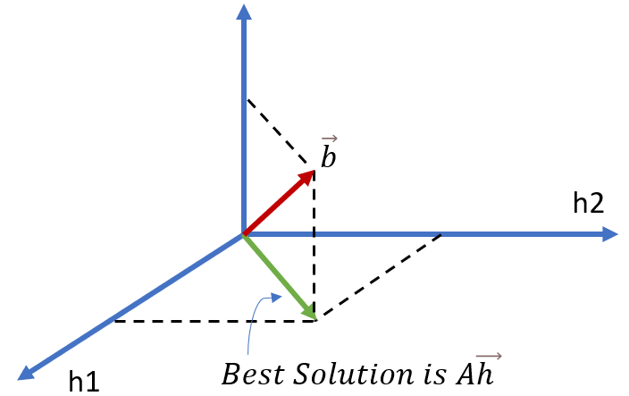

The best choice for $\overrightarrow h$ will bring $A \overrightarrow h$ as close as possible to $\overrightarrow b$. In Other words, the best solution will minimize $\parallel \overrightarrow b - A \overrightarrow h\parallel$. Such a solution would correspont to dropping a perpendicular from $\overrightarrow b \in \Re^m$ to the subspace spanned by $A \overrightarrow h$, as shown in the figure above. Algebraically, the point $\overrightarrow h$, where the perpendicular from $\overrightarrow b$ meets the subspace spanned by $A \overrightarrow h$ is given by $A^T(\overrightarrow b - A \overrightarrow h) = \overrightarrow 0$. In other words, the linear least squares solution for $\overrightarrow h$ must satisfy $(A^TA)\overrightarrow h = A^T \overrightarrow b$, which yields $\overrightarrow h = (A^TA)^{-1}A^T\overrightarrow b = A^+\overrightarrow b$, where $A^+ = (A^TA)^{-1}A^T$ is known as the pseudoinverse of $A$(Note $A^+A = I$). $A^TA$ is a square $n \times n$ matrix whose rank is exactly $n$ by virtue of the act that $rank(A) = n$. $A^TA$ being a sqaure matrix of full rank implies that its inverse $(A^TA)^{-1}$ is guaranteed to exist.(In general, $A^TA$ is symmetric and positive semidefinite. so its eigenvalues are real and non-negative).  
Before leaving the subject of linear least-squares minimization with inhomogeneous equations, let's go back to the begining of this section and re-examine the $h_{33} = 1$ assumption that was used to convert a system of $2N$ homogeneous equations into a system of $2N$ inhomogeneous equations. For most computations of homography between two images recorded under "ordinary" conditions ( regarading the relationship between the camera and the scene), you would be safe with the $h_{33} = 1$ assumption. However, if you are into, say, computational cameras, you may not want to make this assumption.  
The basic problem with the $h_{33} = 1$ assumption is that **it is incompatible with the possibility that a homography may map the orgin in one plane to a point on $l_\infty$ in the other plane.** Let $H$ be a homography from a domain plane to a range plane. The Homogeneous coordinate representation of the orgin in the domain plane is $\begin{pmatrix}0\\0\\1\end{pmatrix}$. In the range plane, this point is mapped to $H.\begin{pmatrix}0\\0\\1\end{pmatrix} = \begin{pmatrix}h_{13}\\h_{23}\\h_{33}\end{pmatrix}$. If for some reason we wanted the mapped point to be on $l_\infty$ in the range plane, we must allow $h_{33}$ to become zero. Obviously, when $h_{33} = 0$, we have $H = \begin{pmatrix} A_{2 \times 2} & \overrightarrow t_{2 \times 1}\\ v_{2 \times 1}^T&0 \end{pmatrix}$. This is obviously not the affine group or any of its subgroups. This type of $H$ belongs only at the root of out transformation hierarchy. In other words, the "distortion" created by this sort of $H$ is purely projective. Note also that we cannot allow $\overrightarrow v$ to become zero sinze otherwise $H$ will become singular.  
It's good to keep in mind that just becase the origin is being mapped to an ideal point down not imply that other point in the vicinity of the origin in the domain plane will also be mapped to infinity in the range plane. Let's consider the point at a unit distance from the orgin on the x-axis in the domain plane. Its image point in the range plane is given by $\begin{pmatrix} h_{11}&h_{12}&h_{13}\\h_{21}&h_{22}&h_{23}\\h_{31}&h_{32}&0\end{pmatrix}\begin{pmatrix}1\\0\\1\end{pmatrix} = \begin{pmatrix} h_{11}+h_{13}\\ h_{21}+h_{23}\\ h_{31}\end{pmatrix}$. which if $h_{31} \neq 0$, some point at finite coordinates in the range plane. As mentioned earlier, at least one of $h_{31}$ and $h_{32}$ must be nonzero.

### Robust Homography Estimation with **RANSAC** Algorithm

The Linear Least-Squares method we saw above can tolerate only a small amount of noise in the $(x,x')$ correspondences. That is, of the measured coordinates for $x$, and $x'$ are off by no more than a couple of pixels from their true values, the algebraic minimization of $\parallel A \overrightarrow h\parallel$ subject to $\parallel \overrightarrow h\parallel = 1$, would still get you a good estimate for the homography. However, when one tries to automate all of the steps required for calculating a homography (that is, when one also tries to figure out the $x_i \leftrightarrow x_i'$ correspondences automatically), the set of correspondences we feed into a homography calculation is likely to contain several false pairings. If the correspondence data we feed into a linear least-squares calculator includes false pairings, we'll surely end up with a strange result for the homography.  
We can think of the merely noisy $(x,x')$ correspondences as constituting the inliers, and the false $(x,x')$ correspondences as constituting the outliers for the calculation of the homography. So what we need is an outlier rejection mechanism before we invoke the linear least-squares method on the inliers, and that takes us to the subject of robust estimation with the RANSAC algorithm. RANSAC stands for "Random Sample Consensus". The goal of robust estimation is to reject outliers. Fundamental to the RANSAC algorithm is using randomly selected least amount of data to construct an estimate and to then ascertain the extent of support that the rest of the data provides to the estimate. We accept the estimate only if the support exceeds a threshold. When an estimate made in this manner is accespted, the supporting data constitutes the inliers and the rest of the data the outliers. After an estimate is accepted, it can be refined using all the inliers. To illustrate RANSAC with a simple example, consider the problem of linear regression. Linear Regression refers to estimating a linear relationship between an input random variable and an output random variable, both assumed to be continuous.  
Consider $x$ and $y$ as two random variables, with $x$ standing for the calendar year and $y$ house prices. Linear regression in this case amounts to estimating a 1-D affine transformation between the two variables : $y = ax + b$, in general any relation can be expressed as $\begin{pmatrix}\overrightarrow y\\1\end{pmatrix} = \begin{pmatrix} A&\overrightarrow b\\\overrightarrow 0^T&1\end{pmatrix}\begin{pmatrix}\overrightarrow x\\1\end{pmatrix} = H\begin{pmatrix}\overrightarrow x\\1\end{pmatrix}$, here $H$ is obviously an affine transformation.

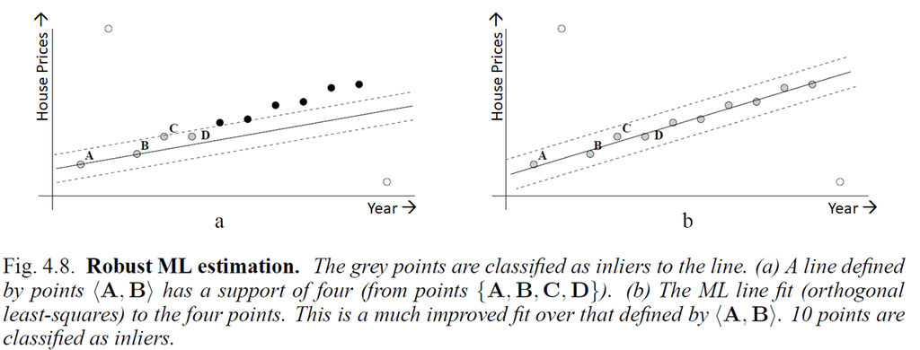

image courstesy: Andrew Zisserman

- Since the least number of points needed to form a line estimate is 2, RANSAC will randomly pick two of the data points, construct a line on the basis of those two points, and then measure the support the rest of the data provides for that line. The support is measured by the number of point that lie within a distance threshold of the line. The point within the distance threshold constitute the inlier set(it is also referred to as the consensus set)
- The Random selection of two points, the formation of a line estimate an the measurement of support for that line is repeated a number of times and the line with the most support is accepted as the robust fit.
- It follow from the last two bullets that the following three parametes are important to te working of the RANSAC algorithm:
  1. We need a decision threshold to construct the inlier set. When we compare a data point with the estimate, of the distance between the two is less than the threshold, we plane it in the inlier set. $\delta$
  2. $N$ for the number of trials to conduct. It is often computationally infeasible to attempt all possible trials
  3. A minimum Value for the size of the inlier set for it to be acceptable. In Most cases, these parameters are set by experimenting with the data. $M$

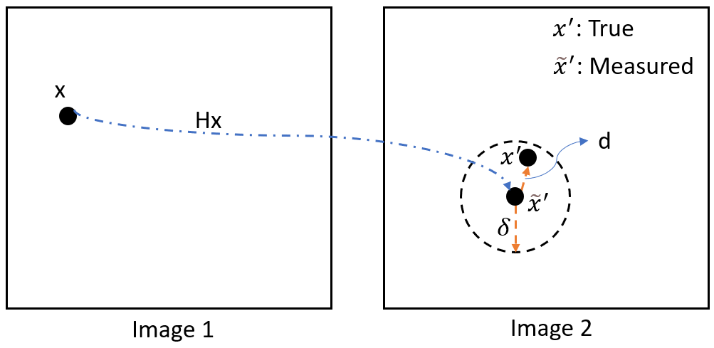

Now we'll see how to set the parameter $N$ for the number of trials, we want to set $N$ large enough so that in at least one trial the minimal set (of size $n$) of the correspondences chosen randomly to construct the homography estimate $H$ does not include any outliers. Let $\epsilon$ be the probability that a randomly chosen $(x,x')$ is an outlier.(If we know that roughly 10% of the correspondences are false, $\epsilon = 0.1$. Then $1-\epsilon$ is the probability that any single correspondence is a true inlier. Therefore, the probability that all $n$ correspondences chose for estimating $H$ in a given trial are all inliers in $(1-\epsilon)^n$. This implies that, in a given trial, the probability that at least one of the $n$ correspondence used for calculating $H$ is an outlier is $1 - (1 - \epsilon)^n$. Therefore, the probability that every one of the $N$ trials will involve at least one outlier in the calculation of $H$ is $[1 - (1 - \epsilon)^n]^N$. Therefore, the probability that at least one of the $N$ trials will be free of outliers in the calculation of $H$ is $p = 1 - [1 - (1 - \epsilon)^n]^N$, we set $N$ so that $p = 0.99$  
Since $1-p = [1 - (1 - \epsilon)^n]^N$, we can also write $N = \log_b(1 - p)$, with $b=1-(1-\epsilon)^n$, Equivalently, $N = \frac{\ln(1-p)}{\ln[1 - (1 - \epsilon)^n]^N}$. To be able to conduct $N$ trials by selecting a fresh set of $n$ correspondences for calculating $H$ in each trial places constraints on the minimum number of correspondences that must be available between the two images. Let $n_{total}$ be the total number of available correspondences. Choosing $n$ correnspondences at a time for each trial means that you'll be able to carry out at most $\frac{n_{total}!}{(n_{total} - n)!n!}$ trials. That takes us to the third parameters of the RANSAC algorithm, $M$. Recall that $M$ is the minimum value for the size of the inlier set for it to be considered acceptable. We want $M$ to be roughly the same as the number of true inliers in the data. So if $\epsilon$ is the probability that a correspondence is an outlier, and if $n_{total}$ is the total number of correspondences between the two images, then $(1-\epsilon).n_{total}$ is the number of inliers in the data. We set $M \simeq (1-\epsilon).n_{total}$

##### Automatic Computation of Homography

The following steps go into automatic calculation of homography between two images:

1. First extract interest points and their descriptors from each images. If interest point extractor is relatively simple, such as the Harris Corner Detector, we can directly use the gray levels in a $W \times W$ window around as its descriptor.
2. you compare each interset point in one image with all the intereset points in the other image using an appropriate similarity criterion. With SIFT and SURF interest points, the similarity criterion can be the Euclidean distance between their descriptor vectors. With Harris Corner points, similarity can be established with sum of squared distances
3. All the $(x,x')$ pairs that pass the similarity test constitute putative set of correspondences. This set will usually be a mixture of noisy and false correspondences.
4. Apply the RANSAC algorithm to find the best inlier set of correspondences, for each trial, use more than 4 but less than 10 randmoly chosen correspondences to calculate a homography $(4<n<10)$ using the linear least squares method.
5. After going through $N$ trials, retain the homography with maximal inlier support and refine it with the inliers.

#### Salutations

1. [Photogrammetric Computer Vision: Statistics, Geometry, Orientation and Reconstruction, by Wolfgang Förstner , Bernhard P. Wrobel](https://www.amazon.in/Photogrammetric-Computer-Vision-Orientation-Reconstruction-ebook/dp/B01LXFI2XF)
2. [Multiple View Geometry in Computer Vision (Second Edition), by Andrew Zisserman](https://www.amazon.in/Multiple-View-Geometry-Computer-Vision/dp/0521540518)